# Multivariante Manova

franmarq@gmail.com

2022-11-04

A continuación aplicaremos un MANOVA a los datos extraidos de la revista estadounidense Motor Trend de 1974 y comprenden el consumo de combustible y 10 aspectos del diseño y rendimiento del automóvil para 32 automóviles (modelos 1973–74).

Las variables incluidas en el conjunto original son las siguientes:

El diccionario de datos del archivo:

[, 1] mpg Miles/(US) gallon [, 2] cyl Number of cylinders [, 3] disp Displacement (cu.in.) [, 4] hp Gross horsepower [, 5] drat Rear axle ratio [, 6] wt Weight (1000 lbs) [, 7] qsec 1/4 mile time [, 8] vs Engine (0 = V-shaped, 1 = straight) [, 9] am Transmission (0 = automatic, 1 = manual) [,10] gear Number of forward gears [,11] carb Number of carburetors

Inicialemnte hacemos una rápida verificación del conjunto, tanto de la estructura como del contenido de las variables:

```r
str(mtcars)
```

```
## 'data.frame':    32 obs. of  11 variables:
##  $ mpg : num  21 21 22.8 21.4 18.7 18.1 14.3 24.4 22.8 19.2 ...
##  $ cyl : num  6 6 4 6 8 6 8 4 4 6 ...
##  $ disp: num  160 160 108 258 360 ...
##  $ hp  : num  110 110 93 110 175 105 245 62 95 123 ...
##  $ drat: num  3.9 3.9 3.85 3.08 3.15 2.76 3.21 3.69 3.92 3.92 ...
##  $ wt  : num  2.62 2.88 2.32 3.21 3.44 ...
##  $ qsec: num  16.5 17 18.6 19.4 17 ...
##  $ vs  : num  0 0 1 1 0 1 0 1 1 1 ...
##  $ am  : num  1 1 1 0 0 0 0 0 0 0 ...
##  $ gear: num  4 4 4 3 3 3 3 4 4 4 ...
##  $ carb: num  4 4 1 1 2 1 4 2 2 4 ...
```

```r
summary(mtcars)
```

```
##       mpg             cyl             disp             hp
##  Min.   :10.40   Min.   :4.000   Min.   : 71.1   Min.   : 52.0
##  1st Qu.:15.43   1st Qu.:4.000   1st Qu.:120.8   1st Qu.: 96.5
##  Median :19.20   Median :6.000   Median :196.3   Median :123.0
##  Mean   :20.09   Mean   :6.188   Mean   :230.7   Mean   :146.7
##  3rd Qu.:22.80   3rd Qu.:8.000   3rd Qu.:326.0   3rd Qu.:180.0
##  Max.   :33.90   Max.   :8.000   Max.   :472.0   Max.   :335.0
##       drat             wt             qsec             vs
##  Min.   :2.760   Min.   :1.513   Min.   :14.50   Min.   :0.0000
##  1st Qu.:3.080   1st Qu.:2.581   1st Qu.:16.89   1st Qu.:0.0000
##  Median :3.695   Median :3.325   Median :17.71   Median :0.0000
##  Mean   :3.597   Mean   :3.217   Mean   :17.85   Mean   :0.4375
##  3rd Qu.:3.920   3rd Qu.:3.610   3rd Qu.:18.90   3rd Qu.:1.0000
##  Max.   :4.930   Max.   :5.424   Max.   :22.90   Max.   :1.0000
##        am              gear            carb
##  Min.   :0.0000   Min.   :3.000   Min.   :1.000
##  1st Qu.:0.0000   1st Qu.:3.000   1st Qu.:2.000
##  Median :0.0000   Median :4.000   Median :2.000
##  Mean   :0.4062   Mean   :3.688   Mean   :2.812
##  3rd Qu.:1.0000   3rd Qu.:4.000   3rd Qu.:4.000
##  Max.   :1.0000   Max.   :5.000   Max.   :8.000
```

Disponemos de 11 variables, algunas son variables categoricas aún cuando están expresadas con numeros, este es el caso de:

vs Engine (0 = V-shaped, 1 = straight) am Transmission (0 = automatic, 1 = manual)

Estas variables al igual que las siguientes serán descartadas para efectos del análisis:

gear Number of forward gears carb Number of carburetors

así nuestro conjunto se reduce a 7 variables en donde la variable cilindros (cyl) sería, para este ejemplo, la variable respuesta del modelo.

Preparamos los datos

```r
#preparamos los datos para su análisis, nos vamos a quedar con las variables numericas y como variable respuesta 'cilindors'
yvars<- cbind(mtcars$mpg, mtcars$disp, mtcars$hp, mtcars$drat,mtcars$wt, mtcars$qsec)
colnames(yvars) <-c("mpg","disp","hp","drat","wt","qsec")

#creo un conjunto solo con las variables a analizar, esto para facilitar análisis, graficas y validacion de supuestos posteriores. Convertimos a caracter la variable cilindros

mtcars1<-mtcars
mtcars1$cil<-as.character(mtcars$cyl)
mtcars1$cyl <- NULL
mtcars1$vs <- NULL
mtcars1$am <- NULL
mtcars1$gear <- NULL
mtcars1$carb <- NULL
str(mtcars1)
```

```
## 'data.frame':    32 obs. of  7 variables:
##  $ mpg : num  21 21 22.8 21.4 18.7 18.1 14.3 24.4 22.8 19.2 ...
##  $ disp: num  160 160 108 258 360 ...
##  $ hp  : num  110 110 93 110 175 105 245 62 95 123 ...
##  $ drat: num  3.9 3.9 3.85 3.08 3.15 2.76 3.21 3.69 3.92 3.92 ...
##  $ wt  : num  2.62 2.88 2.32 3.21 3.44 ...
##  $ qsec: num  16.5 17 18.6 19.4 17 ...
##  $ cil : chr  "6" "6" "4" "6" ...
```

Realizaremos en primer lugar un análisis MANOVA para comprobar la igualdad de los grupos según los diferentes tipos (números) de cilindros:

```r
mma<-manova(yvars ~ cil, data=mtcars1)
mma
```

```
## Call:
##    manova(yvars ~ cil, data = mtcars1)
##
## Terms:
##                      cil Residuals
## mpg                824.8     301.3
## disp            398891.0   77293.8
## hp              104030.5   41696.3
## drat                 4.4       4.5
## wt                  18.2      11.5
## qsec                34.6      64.4
## Deg. of Freedom        2        29
##
## Residual standard errors: 3.223099 51.62659 37.91839 0.3938298 0.6298047 1.489994
## Estimated effects may be unbalanced
```

parece haber diferencias entre las variables según el número de cilindros. Si obtenemos los contrastes mas aplicados en este caso:

```r
summary(mma, test="Wilks")
```

```
##           Df    Wilks approx F num Df den Df    Pr(>F)
## cil        2 0.064564   11.742     12     48 1.542e-10 ***
## Residuals 29
## ---
## Signif. codes:  0 '***' 0.001 '**' 0.01 '*' 0.05 '.' 0.1 ' ' 1
```

```r
summary(mma, test="Roy")
```

```
##           Df    Roy approx F num Df den Df    Pr(>F)
## cil        2 9.8951    41.23      6     25 8.875e-12 ***
## Residuals 29
## ---
## Signif. codes:  0 '***' 0.001 '**' 0.01 '*' 0.05 '.' 0.1 ' ' 1
```

```r
summary(mma, test="Hotelling-Lawley")
```

```
##           Df Hotelling-Lawley approx F num Df den Df    Pr(>F)
## cil        2           10.317   19.774     12     46 2.936e-14 ***
## Residuals 29
## ---
## Signif. codes:  0 '***' 0.001 '**' 0.01 '*' 0.05 '.' 0.1 ' ' 1
```

```r
summary(mma, test="Pillai")
```

```
##           Df Pillai approx F num Df den Df    Pr(>F)
## cil        2 1.2048   6.3127     12     50 1.249e-06 ***
## Residuals 29
## ---
## Signif. codes:  0 '***' 0.001 '**' 0.01 '*' 0.05 '.' 0.1 ' ' 1
```

El resultado obtenido para todos los contrastes, todos con p-valor menor a 0.05, indica que existen diferencias entre los vectores medias de los tres tipos de cilindros (números de cilindros en motores).

Contrastes marginales de medias Hemos contrastado la igualdad de medias conjuntas, en este caso haremos los contrastes marginales.

```r
# mtcars$mpg, mtcars$cyl, mtcars$disp, mtcars$hp, mtcars$drat,mtcars$wt, mtcars$qsec, mtcars$gear, mtcars$vs)
modelo1<-aov(mtcars1$mpg ~ mtcars1$cil )
summary(modelo1)
```

```
##             Df Sum Sq Mean Sq F value   Pr(>F)
## mtcars1$cil  2  824.8   412.4    39.7 4.98e-09 ***
## Residuals   29  301.3    10.4
## ---
## Signif. codes:  0 '***' 0.001 '**' 0.01 '*' 0.05 '.' 0.1 ' ' 1
```

```r
modelo2<-aov(mtcars1$disp ~ mtcars1$cil )
summary(modelo2)
```

```
##             Df Sum Sq Mean Sq F value   Pr(>F)
## mtcars1$cil  2 398891  199445   74.83 3.55e-12 ***
## Residuals   29  77294    2665
## ---
## Signif. codes:  0 '***' 0.001 '**' 0.01 '*' 0.05 '.' 0.1 ' ' 1
```

```r
modelo3<-aov(mtcars1$hp ~ mtcars1$cil )
summary(modelo3)
```

```
##             Df Sum Sq Mean Sq F value   Pr(>F)
## mtcars1$cil  2 104031   52015   36.18 1.32e-08 ***
## Residuals   29  41696    1438
## ---
## Signif. codes:  0 '***' 0.001 '**' 0.01 '*' 0.05 '.' 0.1 ' ' 1
```

```r
modelo4<-aov(mtcars1$drat ~ mtcars1$cil )
summary(modelo4)
```

```
##             Df Sum Sq Mean Sq F value   Pr(>F)
## mtcars1$cil  2  4.364  2.1822   14.07 5.36e-05 ***
## Residuals   29  4.498  0.1551
## ---
## Signif. codes:  0 '***' 0.001 '**' 0.01 '*' 0.05 '.' 0.1 ' ' 1
```

```r
modelo5<-aov(mtcars1$wt ~ mtcars1$cil )
summary(modelo5)
```

```
##             Df Sum Sq Mean Sq F value   Pr(>F)
## mtcars1$cil  2  18.18   9.088   22.91 1.07e-06 ***
## Residuals   29  11.50   0.397
## ---
## Signif. codes:  0 '***' 0.001 '**' 0.01 '*' 0.05 '.' 0.1 ' ' 1
```

```r
modelo6<-aov(mtcars1$qsec ~ mtcars1$cil )
summary(modelo6)
```

```
##             Df Sum Sq Mean Sq F value  Pr(>F)
## mtcars1$cil  2  34.61   17.30   7.794 0.00196 **
## Residuals   29  64.38    2.22
## ---
## Signif. codes:  0 '***' 0.001 '**' 0.01 '*' 0.05 '.' 0.1 ' ' 1
```

Del resultado de los contrastes marginales podemos observar que individualemte para cada una de las variables se observan diferencias significativas en las medias para cada tipo de numero de cilindros

Obtengamos ahora una representación grafica del conjunto para visualizar distribución, comportamiento bivariante y segemntación por cada grupo de cilindros:

```r
require(RColorBrewer)
colors <- brewer.pal(nlevels(mtcars1$cil),"Dark2")
require(car)
```

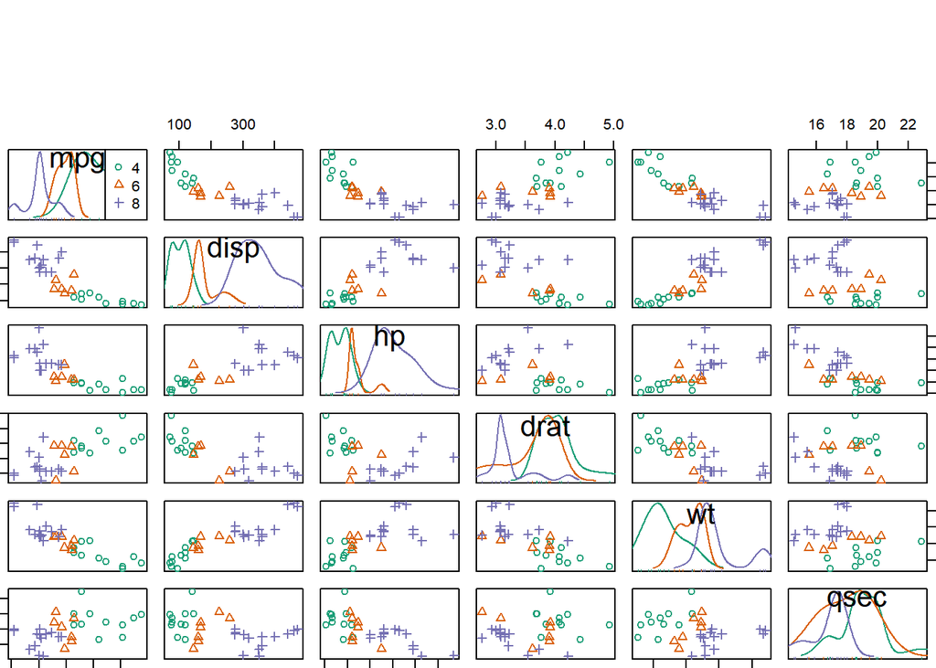

```r
scatterplotMatrix(mtcars1[1:6],groups=mtcars1[[7]],
smooth=FALSE,regLine=FALSE, legend=T, oma=c(0,0,8,0),
col=colors)
```

```r
#legend("top",legend=levels(mtcars1[[7]],pch=1:3,col=colors,horiz=TRUE,bty="n",
#cex=1.5,xpd=TRUE)
```

A continuación contrastaremos las hipotesis que sustentan el modelo

1. Normalidad:

Debemos validar que el conjunto de datos se comporta como una normal multivariante

```r
require(MVN)
mvn(data =mtcars1[1:6] , univariateTest = "SW", desc = T)
```

```
## $multivariateNormality
##            Test       HZ     p value MVN
## 1 Henze-Zirkler 1.046162 0.001459679  NO
##
## $univariateNormality
##           Test  Variable Statistic   p value Normality
## 1 Shapiro-Wilk    mpg       0.9476    0.1229    YES
## 2 Shapiro-Wilk   disp       0.9200    0.0208    NO
## 3 Shapiro-Wilk    hp        0.9334    0.0488    NO
## 4 Shapiro-Wilk   drat       0.9459    0.1101    YES
## 5 Shapiro-Wilk    wt        0.9433    0.0927    YES
## 6 Shapiro-Wilk   qsec       0.9733    0.5935    YES
##
## $Descriptives
##       n       Mean     Std.Dev  Median    Min     Max      25th   75th
## mpg  32  20.090625   6.0269481  19.200 10.400  33.900  15.42500  22.80
## disp 32 230.721875 123.9386938 196.300 71.100 472.000 120.82500 326.00
## hp   32 146.687500  68.5628685 123.000 52.000 335.000  96.50000 180.00
## drat 32   3.596563   0.5346787   3.695  2.760   4.930   3.08000   3.92
## wt   32   3.217250   0.9784574   3.325  1.513   5.424   2.58125   3.61
## qsec 32  17.848750   1.7869432  17.710 14.500  22.900  16.89250  18.90
##           Skew    Kurtosis
## mpg  0.6106550 -0.37276603
## disp 0.3816570 -1.20721195
## hp   0.7260237 -0.13555112
## drat 0.2659039 -0.71470062
## wt   0.4231465 -0.02271075
## qsec 0.3690453  0.33511422
```

Se puede observar que las variables de forma conjunta no son normales, ya que el p-value del test resulto en 0.001 menor a 0.05 para una prueba al 95% de confianza. De forma marginal, las que no resultaron normales fueron: desplazamiento (disp) y caballos de fuerza (hp).

2. Igualdad de las matrices de varianzas covarianzas: Ahora, contrastamos la hipótesis sobre igualdad de las matrices de varianzas covarianzas.

```r
by(mtcars1[,-7], mtcars1$cil, var)
```

```
## mtcars1$cil: 4
##              mpg       disp         hp        drat          wt       qsec
## mpg   20.3385455 -97.583545 -49.424545  0.69923636 -1.83191091 -1.7903091
## disp -97.5835455 722.082545 244.484545 -4.91523636 13.10932091 14.8188091
## hp   -49.4245455 244.484545 438.254545 -3.59763636  1.90629091 -6.2820909
## drat   0.6992364  -4.915236  -3.597636  0.13356909 -0.09968073 -0.1742373
## wt    -1.8319109  13.109321   1.906291 -0.09968073  0.32440282  0.6113902
## qsec  -1.7903091  14.818809  -6.282091 -0.17423727  0.61139018  2.8306218
## ------------------------------------------------------------
## mtcars1$cil: 6
##              mpg        disp          hp         drat          wt        qsec
## mpg   2.11285714    6.227619   -4.480952   0.07938095 -0.35302381  -1.0388571
## disp  6.22761905 1727.438095 -517.904762 -16.44409524  6.99838095  55.9617143
## hp   -4.48095238 -517.904762  588.571429   2.50809524 -2.64738095 -26.0057143
## drat  0.07938095  -16.444095    2.508095   0.22662857 -0.06016429  -0.5063143
## wt   -0.35302381    6.998381   -2.647381  -0.06016429  0.12698214   0.5267071
## qsec -1.03885714   55.961714  -26.005714  -0.50631429  0.52670714   2.9133905
## ------------------------------------------------------------
## mtcars1$cil: 8
##               mpg        disp           hp        drat         wt        qsec
## mpg    6.55384615  -90.178462  -37.0153846  0.04569231 -1.2643692  -0.3194615
## disp -90.17846154 4592.952308  408.5461538 -2.32561538 38.8713923  15.8160769
## hp   -37.01538462  408.546154 2598.6428571 12.67708791  0.6820275 -46.0620330
## drat   0.04569231   -2.325615   12.6770879  0.13865330 -0.1017598  -0.3667445
## wt    -1.26436923   38.871392    0.6820275 -0.10175984  0.5766956   0.4873249
## qsec  -0.31946154   15.816077  -46.0620330 -0.36674451  0.4873249   1.4304489
```

contraste de igualdad de matrices de varianzas

```r
require(biotools)
boxM(mtcars1[,-7], mtcars1$cil)
```

```
##
##  Box's M-test for Homogeneity of Covariance Matrices
##
## data:  mtcars1[, -7]
## Chi-Sq (approx.) = 88.45, df = 42, p-value = 3.708e-05
```

El resultado anterior nos indica rechazar la hipotesis nula, en otras palabras, las matrices de varianzas covarianzas son estadítsicamente difererentes.